# Zachary Sullivan CSCI E-83 Graduate Final Report

## Modeling Video Game Sales

### Executive summary - The importance of games

This document details the analysis and evaluation of the profitability of video game genres in a diverse suite of geographic regions. This project utilizes the Kagel 'Video Game Sales' dataset to model the preference of gamers based on historical game sales [[1]](https://www.kaggle.com/gregorut/videogamesales).

The scale of the video game industry can at times be difficult to grasp. With a catelog of titles dating back to the classic Atari pong, the video game industry has ballooned to \$155 billion in 2020, with expectations of the industry surging to \\$200 billion in 2023 [[2]](https://www.juniperresearch.com/researchstore/content-digital-media/video-games-market-report). As the scale of the video game industry continues to increase, so too is the ferocity of competition between developers aiming at becoming the next major gaming phenomina. With highly sucessful titles like 'Fortnite' generating revenues exceess of \$300 million in April 2020 alone, developers are facing the problem of increasing pressure from investors to find the next highly successful gaming genre [[3]](https://venturebeat.com/2020/06/15/epic-games-shareholders-seeking-to-sell-stake-for-750-million-at-17-billion-valuation/).

### Introduction - Problem Statement and Summary Findings

To forcast the success of future games in various geographical regions, this project utilizes the Kaggle 'Video Game Sales' dataset to model the preference of gamers based on historical game sales [[1]](https://www.kaggle.com/gregorut/videogamesales). With emerging new consoles from Playstation and Microsoft (recently released in 2020), developers are now presented with the opportunity to captialize on new and emerging platforms still in their infancy. This opportunity highlights a need to provide developers with a model to better understand potential target markets.

In reviewing the Exploratory Data Analysis (EDA) for popular genres by region sales, there are clear preferntial differences. While European and North American gamers perfer action titles and shooters, Japanese players perfer role-rlaying games signficantly more. This report will begin by presenting developers with a suite of frequenist models to visualize how game sales are impacted by genre. Following which, readers will be presented with a Bayesian model to simulate and predict the success of a game based on the prior distrubtion of genre's historical sales from a sister sales region. Here success is defined as a game that recieves a minimum of \1 million units sold.

The paper attempts to address the following key results: to better understand the relationship between game sales and their coresponding genre. To better understand how game genres drive sales in a given region, and showcase how customer purchase preferences have evolved over time. Inform publishers on what games will likely succeed based on their projected genre grouping. Each of these key results is aimed towards optimizing publisher investments, potentially avoiding occurances where game publishers invest in a video game title that will likely underperform.

## Exploratory Data Analysis

```python
import pandas as pd
import numpy as np
import statsmodels.api as sm
import seaborn as sns
import scipy
import matplotlib.pyplot as plt
import numpy.random as nr
import math
```

### Overview of dataset (columns, datatypes)

The 'Video Game Sales' dataset contains historical video games sales with more than 100,000 copies solid. As presented in the following exporatory data analysis (EDA) section, the preferences of gamers vary by region. The following data analysis explores potential issues and missing data from the dataset. Specifically, the EDA addresses missing elements for both year and publisher information. Following this, will be a visualization to communicate the market scale of video games globaly. Furthermore, this section will provide evidence for the diverse preferences of gamers from various geographical regions, and showcase how these geographical preferences impact game sales.

- Overview of the dataset(columns, datatypes)
- Overview of any and all missing data
- Dataset statistics (how many games, genres, publishers, regions, etc.)
- Visualizations
  - popularity of genres based on sales globally, and per region
  - success of publishers based on sales globally, and per region
  - relevancy of features using heatmap

```python
# Import dataset, and provide overview of data
vgsales = pd.read_csv('data/vgsales.csv')
vgsales.head()
```

|  | Rank | Name | Platform | Year | Genre | Publisher | NA_Sales | EU_Sales | JP_Sales | Other_Sales | Global_Sales |
| --- | --- | --- | --- | --- | --- | --- | --- | --- | --- | --- | --- |
| 0 | 1 | Wii Sports | Wii | 2006.0 | Sports | Nintendo | 41.49 | 29.02 | 3.77 | 8.46 | 82.74 |
| 1 | 2 | Super Mario Bros. | NES | 1985.0 | Platform | Nintendo | 29.08 | 3.58 | 6.81 | 0.77 | 40.24 |
| 2 | 3 | Mario Kart Wii | Wii | 2008.0 | Racing | Nintendo | 15.85 | 12.88 | 3.79 | 3.31 | 35.82 |
| 3 | 4 | Wii Sports Resort | Wii | 2009.0 | Sports | Nintendo | 15.75 | 11.01 | 3.28 | 2.96 | 33.00 |
| 4 | 5 | Pokemon Red/Pokemon Blue | GB | 1996.0 | Role-Playing | Nintendo | 11.27 | 8.89 | 10.22 | 1.00 | 31.37 |

```python
print('Dataframe dimensions: ' + str(vgsales.shape))
```

```
Dataframe dimensions: (16598, 11)
```

```python
stats = ['Name', 'Publisher', 'Platform', 'Genre']
for stat in stats:
    print('Unique ' + stat + 's : ' + str(len(vgsales[stat].unique())))
```

```
Unique Names : 11493
Unique Publishers : 579
Unique Platforms : 31
Unique Genres : 12
```

### Overview of any and all missing data

The following section addresses any and all missing or incorrect data within the raw dataset. To achive this we begin with a comparison on entry counts between all dataset columns. Leveraging pandas.Dataframe.info method showcases information related per-column entry counts and entry datatypes. Here we can see that both year and publisher columns feature missing data (as denoted by the differening "Non-Null Count" values.)

```python
vgsales.info(verbose = True, show_counts = True)
```

```
<class 'pandas.core.frame.DataFrame'>
RangeIndex: 16598 entries, 0 to 16597
Data columns (total 11 columns):
 #   Column        Non-Null Count  Dtype
---  ------        --------------  -----
 0   Rank          16598 non-null  int64
 1   Name          16598 non-null  object
 2   Platform      16598 non-null  object
 3   Year          16327 non-null  float64
 4   Genre         16598 non-null  object
 5   Publisher     16540 non-null  object
 6   NA_Sales      16598 non-null  float64
 7   EU_Sales      16598 non-null  float64
 8   JP_Sales      16598 non-null  float64
 9   Other_Sales   16598 non-null  float64
 10  Global_Sales  16598 non-null  float64
dtypes: float64(6), int64(1), object(4)
memory usage: 1.4+ MB
```

The issue of missing entries is further reinforced through the summation of null values within each column. Here we can see that both Year and Publisher are the only columns that feature null values.

```python
# Computes the sum of all null value entries within a given dataframe
# @param df The dataframe to analyize
# @return column/nullVal key pairs as Series
def getNullCounts(df):

    nullVals = {} # Dictionary records the column and null value summation

    for col in vgsales.columns:
        nullVals[col] = df[col].isnull().sum()

    return pd.Series(nullVals, index=nullVals.keys())

print(getNullCounts(vgsales))
```

```
Rank              0
Name              0
Platform          0
Year            271
Genre             0
Publisher        58
NA_Sales          0
EU_Sales          0
JP_Sales          0
Other_Sales       0
Global_Sales      0
dtype: int64
```

Before expunging these null entries, we must confirm the entry dates are within the expected yearly range. Given the dataset leverages the industry website 'Vgcharz' [[4]](https://www.vgchartz.com/) (who at the time of the creation of this dataset), features sales data until the year 2017.

```python
print('Minimum year in dataset: ' + str(vgsales['Year'].min()))
print('Maximum year in dataset: ' + str(vgsales['Year'].max()))
```

```
Minimum year in dataset: 1980.0
Maximum year in dataset: 2020.0
```

While the minimum year value falls within the expected range, the dataset only contains entries up to 2017. Therefore the maximum year of 2020 is clearly a mistake. As such, all entries that feature the year 2020 will need to be manually updated or removed.

Interestingly, there is only one row that features a publication year of 2020, therefore this should be an easy manual fix. A quick google search should provide the offical release date for this game.

```python
rows = list(vgsales['Year'][vgsales['Year'] == vgsales['Year'].max()].index)
print(rows)

vgsales.loc[rows]
```

```
[5957]
```

|  | Rank | Name | Platform | Year | Genre | Publisher | NA_Sales | EU_Sales | JP_Sales | Other_Sales | Global_Sales |
| --- | --- | --- | --- | --- | --- | --- | --- | --- | --- | --- | --- |
| 5957 | 5959 | Imagine: Makeup Artist | DS | 2020.0 | Simulation | Ubisoft | 0.27 | 0.0 | 0.0 | 0.02 | 0.29 |

```python
# Manually update the faulty Year entry given the known entry Name
vgsales.loc[vgsales['Name'] == 'Imagine: Makeup Artist', 'Year'] = 2009

# Confirm the faulty entry is updated
vgsales.loc[vgsales['Name'] == 'Imagine: Makeup Artist']
```

|  | Rank | Name | Platform | Year | Genre | Publisher | NA_Sales | EU_Sales | JP_Sales | Other_Sales | Global_Sales |
| --- | --- | --- | --- | --- | --- | --- | --- | --- | --- | --- | --- |
| 5957 | 5959 | Imagine: Makeup Artist | DS | 2009.0 | Simulation | Ubisoft | 0.27 | 0.0 | 0.0 | 0.02 | 0.29 |

```python
# The remaining missing values may take longer to manually adjust, therefore I will simply expunge these entries.
vgsales.dropna(inplace=True)
getNullCounts(vgsales)
```

```
Rank            0
Name            0
Platform        0
Year            0
Genre           0
Publisher       0
NA_Sales        0
EU_Sales        0
JP_Sales        0
Other_Sales     0
Global_Sales    0
dtype: int64
```

### Dataset Visualizations

Despite early renditions of video games as simple novelties distributed by software developers amongst one and other, the video game industry has subsequently witnessed a rapid evolution in product and publisher diversity. As the accessability of mobile devices widens to accomodate a truely global audience, so too has the adoption of video games as a dominate entertainment medium. The intent of this section is to communicate the diversity and scale of video game sales across various global sales regions. First, let us generate a comparison of the various game genres across each geographic region. Genres will be plotted against region sales.

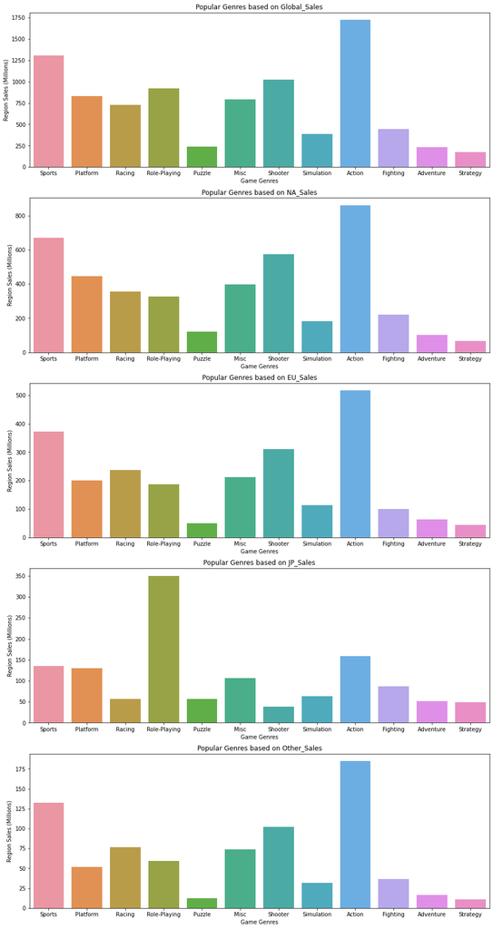

```python
# Popular Genres globally, and per region
sales_groups = ['Global_Sales', 'NA_Sales', 'EU_Sales', 'JP_Sales', 'Other_Sales']
genres = vgsales['Genre'].unique()

fig, axes = plt.subplots(len(sales_groups), 1, figsize=(15, 30))

# Iterate through each sales region, obtaining the total sales for the given genre
for i, sg in enumerate(sales_groups):
    sales = []
    for g in vgsales['Genre'].unique():
        sales.append(vgsales[vgsales.Genre==g][sg].sum())

    sns.barplot(ax=axes[i], x=genres, y=sales)
    axes[i].set_title('Popular Genres based on ' + sg)
    axes[i].set_xlabel('Game Genres')
    axes[i].set_ylabel('Region Sales (Millions)')
```

The plots of game genres against region sales showcases a perferencial difference between gamers across the world. Here we can see that game enthusiats in Japan vastly prefer role-playing style games, with minimal interest in first person shooters. This runs contrary to western markets, including North America and Europe, where action, shooters and sports games are dominate market players. With a clear indication that game genre perferences vary by region, a predictive model to simulate game sales based on genre may prove useful to publishers.

A comparison of region sales must also be made. Specifically comparing Japanese and Western (European and North American) sales regions. Despite the comparitively smaller sales values between these two regions, a consideration of each region popuation must be taken into account. According to 2018 research findings conducted by The Nielsen Corporation, nearly two-thirds of the U.S. population identify as gamers. With year over year growth, the North American sales region clearly offers developers and publishers a growing customer base [[5]](https://www.nielsen.com/us/en/insights/report/2018/us-games-360-report-2018/). The Japanese sales region also offers a publishers a growing customer pool, with household video game participation rates increasing between 1996 and 2016 (2016 Survey on Time Use and Leisure Activities from Japanese Ministry of Internal Affairs and Communications) [[6]](http://www.e-stat.go.jp/SG1/estat/XlsdlE.do?sinfid=000031594636).

Given the previous visualization, let us now compare the popularity of game publishers across each geographic region. Publisher popularity will be plotted against region sales.

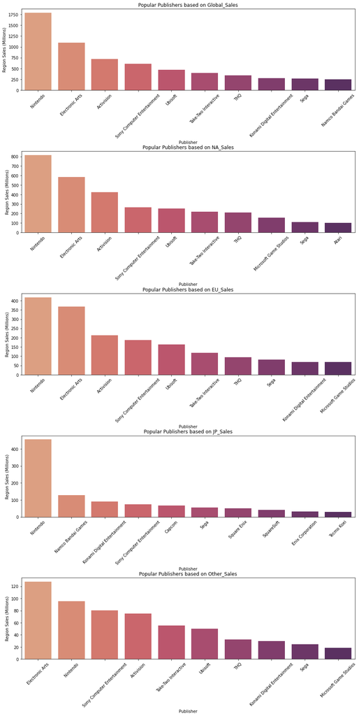

```python
# Popular publishers globally, and per region
fig, axes = plt.subplots(len(sales_groups), 1, figsize=(15, 30))
fig.subplots_adjust(hspace=0.75)

for i, sg in enumerate(sales_groups):

    publishers = vgsales.groupby('Publisher')[sg].sum().reset_index()
    publishers = publishers.sort_values(sg, ascending=False)
    sns.barplot(
        ax=axes[i], x=publishers['Publisher'][:10],
        y=publishers[sg], palette=sns.color_palette('flare', n_colors=10))
    axes[i].set_title('Popular Publishers based on ' + sg)
    axes[i].set_ylabel('Region Sales (Millions)')


    for tick in axes[i].get_xticklabels():
        tick.set_rotation(45)
```

The visualizations of popular publishers by region sales showcases that most sales regions are dominated by Nintendo, despite western gamers predominately enjoying action titles. This is particcularly interesting as Nintendo is often associated with the publication of platforming games (such as Super Mario Bros). Yet Nintendo has clearly diversified their portfolio of titles to better target game enthusiasts in all regions. Furthermore, it should be noted that while North American and European sales regions feature a diverse pool of 10 popular western and Japanese publishers, the Japanese sales region solely features Japanese publishers in the top 10 best sellers. This may suggest potential difficulty for western publishers to penetrate the Japanese market, potentially grounded on cultural preferences or greater market maturity resulting in a stronger market hold by historical players.

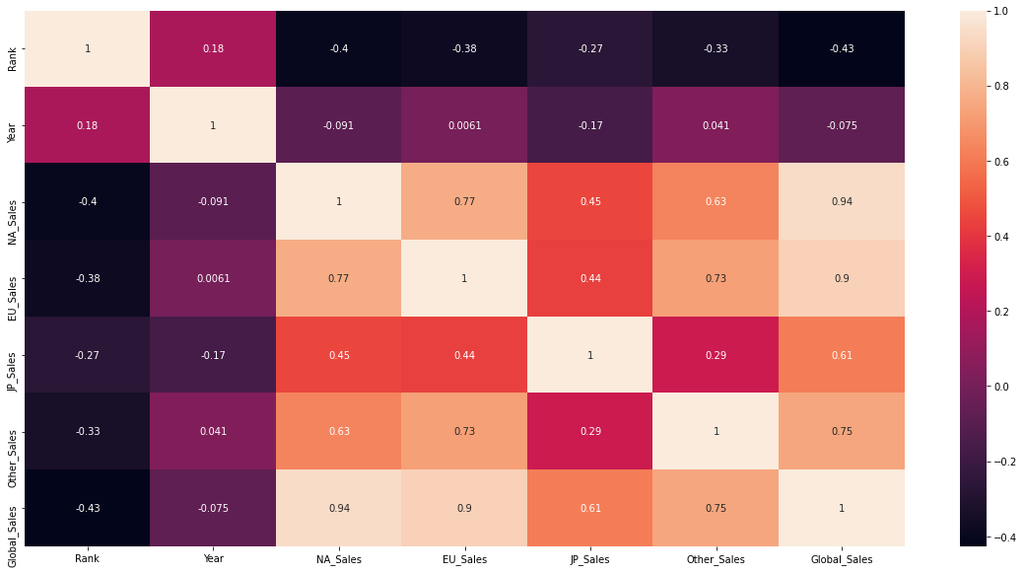

```python
plt.figure(figsize=(20, 10))
cor = vgsales.corr()
sns.heatmap(cor, annot=True)
plt.show()
```

The following heatmap suggests the publication year has a weak correlation to all other features, where regional sales have a strong correlation to one and other. Furthermore, the rank of a given game has a negative correlation to game sales. This makes sense given the large number of games included in the dataset are often games with relatively small sales numbers. However, I am suprised to see the publication year to feature such a weak correlation to regional sales, my intial assumption relied on the increasing yearly popularity of games to drive sales. This weak correlation suggests otherwise. Additionally, both North American and European sales have a stronger corrleation to global sales than sales in Japan. Despite the popularity of games in Japan's youth culture, this relationship suggests to me that regional population values are likely more important to Global sales figures.

# Data Models

The exploratory data analysis of the Kagel 'Video Game Sales' dataset has reinforced the fact that consumer preferences vary significantly between geographic sales regions. Furthermore, analysis of the dataset suggests that these non-uniform purchase decisions are likely infuenced further by market maturity, product saturation and regional publisher dominance. These insights underpin the need for more formal analytical methods to properly model profitabilty and growth of game genres within all sales regions. The following section will describe the use of frequentist and bayesian models to better understand the problem of current and future game genre growth.

## Understanding Mean Estimates of gaming genres per-region.

We begin by performing a nonparametric resampling of genre sales. A bootstrap resampling process was selected in order to better understand and estimate the mean sales performance of game genres in their respective sales region. However, given the relatively small number of unique per-genre titles that are particularly prevelant in earlier years of the dataset, the use of a bootstrap resampling process may result in potentially biased values. Drawing upon the central limit theorem (CLT), we see that each genre distribution appears normally distributed as expected. The resulting Q-Q plots confirm this. However, there do appear to be a few bootstrap distributions which do not quite appear Normally distributed. For instance, Global Sports genre sales appear to slightly deviate from a Normal distribution and indicate a fair amount of skewness.

A valuable insight to be made is the comparative difference in mean genre sales between two seperate regions. For instance, what inferences can be made between the differences in sales performance of action game sales sold in the North American region versus European. Potenitally these similar sales regions could be used as a predictor in our bayesian model for yearly predictions.

```python
# Obtains all genre sales in a given region, returns as key/val dictionary
# @param df The dataframe to query
# @param region The queried region
# @return dictionary of genres and sales values
def get_region_genre_sales(df, region):

    # Validate if df has a region column
    if region in df.columns:
        genre_sales = {}

        # Iterate through each unique genre and append all sales values
        for genre in df['Genre'].unique():
            genre_sales[genre] = df[df.Genre==genre][region]

        return genre_sales
    else:
        return None

# Obtain and record each region's genre sales values
global_genre_sales = get_region_genre_sales(vgsales, 'Global_Sales')
na_genre_sales = get_region_genre_sales(vgsales, 'NA_Sales')
eu_genre_sales = get_region_genre_sales(vgsales, 'EU_Sales')
jp_genre_sales = get_region_genre_sales(vgsales, 'JP_Sales')
other_genre_sales = get_region_genre_sales(vgsales, 'Other_Sales')
```

```python
# CITATION: The following non-parametric bootstrap resampling functions were created following
# .. Professor Stephen F. Elston's 2020-2021 Lecture 14 material and is credited as the original author.

# Computes and plots a matrix of bootstrap distributions and estimates
# @param genre_sales A dictionary of genre sales key value pairs
# @param samples     The number of bootstrap samples to compute
# @param title       The title of the matrix plot
# @param x_label     The x axis label for each matrix plot
def plot_hist_matrix(genre_sales, samples, title, x_label):
    if genre_sales is None:
        raise Exception("Input matrix cannot be null")

    n_rows = round(math.sqrt(len(genre_sales)))
    n_cols = round(len(genre_sales)/n_rows)

    # Create subplots
    figA, axesA = plt.subplots(nrows=n_rows, ncols=n_cols, figsize=(25,25))
    figB, axesB = plt.subplots(nrows=n_rows, ncols=n_cols, figsize=(25,25))
    # Iterate through dictionary of genre sales
    for i, genre in enumerate(genre_sales):
        axA = axesA[i//n_cols, i%n_cols]
        axB = axesB[i//n_cols, i%n_cols]

        # Compute a new bootstrap resample with n resamples
        bootstrap_mean_estimate, boot_means = bootstrap_mean(genre_sales[genre], samples)

        sm.qqplot(pd.Series(boot_means), fit=True, line="45", ax=axB)
        axB.set_title(genre + title)


        sns.histplot(boot_means, kde=True, ax=axA)
        axA.axvline(x=bootstrap_mean_estimate, color='red', linestyle='dashed', linewidth=4)

        axA.set_xlabel(x_label)
        axA.set_title(genre + title)

    plt.show()

# Computes a resample of n samples for a genre's sales, returning the bootstrap mean
# @param genre_sales The sales values for the given region's genre
# @param samples     The number of samples to compute
# @return            A tuple containing the resamples and bootstrap estimate
def bootstrap_mean(genre_sales, samples):
    resamples = []

    # Append the resamples and compute the mean
    for i in range(samples):
        # Randomly sample n times with replacement
        resamples.append(np.mean(nr.choice(genre_sales, size=len(genre_sales), replace=True)))

        # Continuously recompute the bootstrap estimate
        mean_estimate = np.mean(resamples)

    return (mean_estimate, resamples)
```

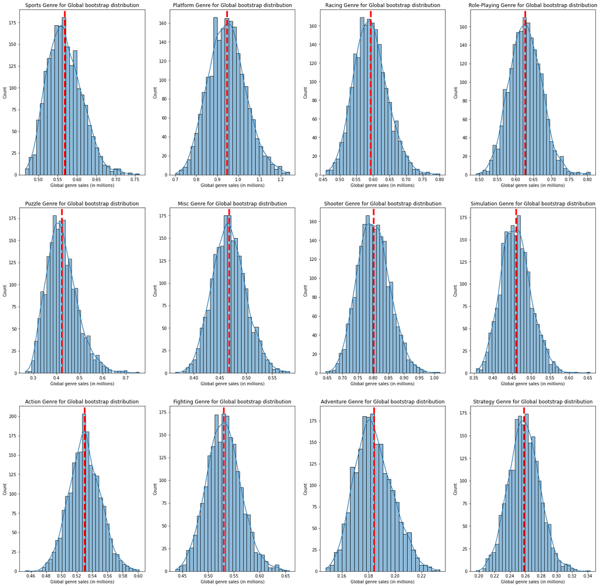

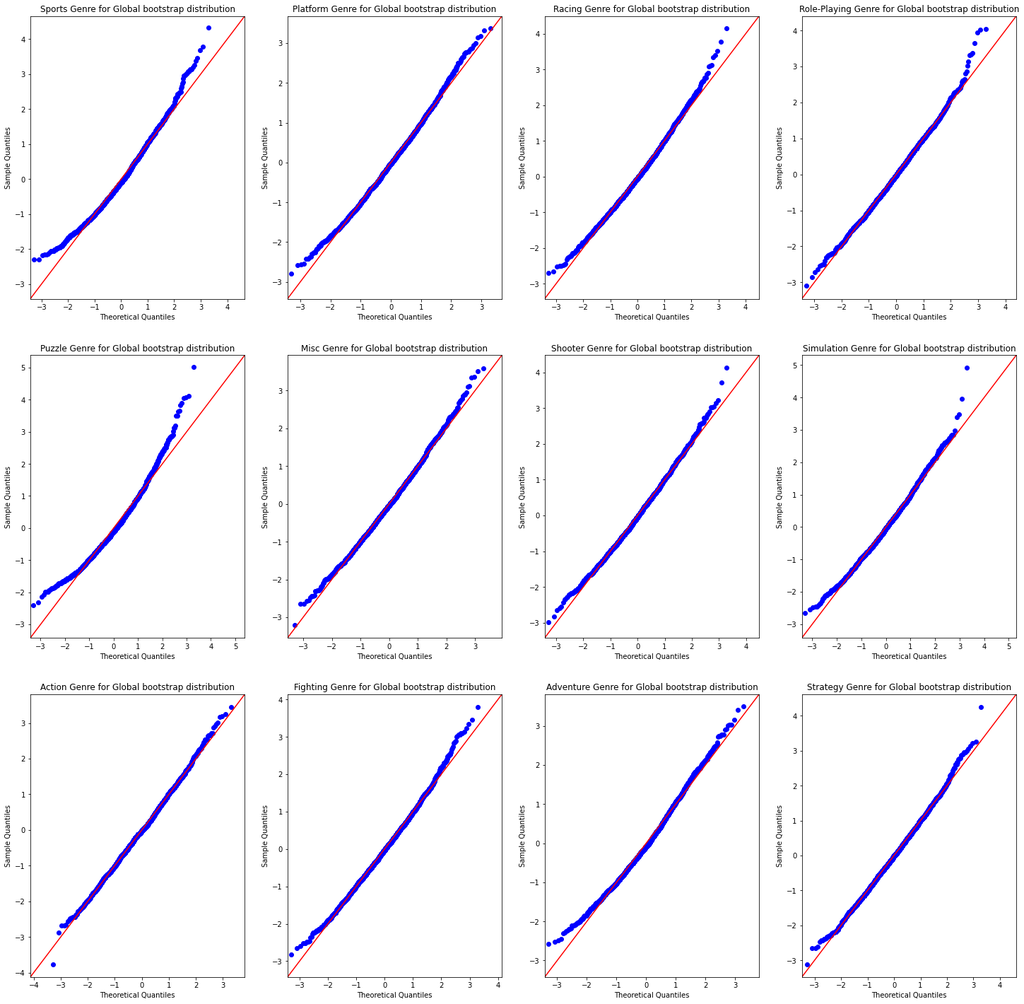

```python
plot_hist_matrix(global_genre_sales, 2000, ' Genre for Global bootstrap distribution', 'Global genre sales (in millions)')
```

```python
# CITATION: The following two-sample bootstrap resampling function was created following
# .. Professor Stephen F. Elston's 2020-2021 Lecture 14 material and is credited as the original author.

# Compute a two-sample bootstrap point estimate of given genre region's sales
# @param sample_A  The first of two samples to compute
# @param sample_B  The second of two samples to compute
# @param n_samples The number of bootstrap samples to compute
def two_sample_bootstrap_mean(sample_A, sample_B, n_samples):
    resamples = []
    # Append the resamples and compute the mean
    for i in range(n_samples):
        # independantly perform random sample n times with replacement
        sample_A_boots = np.mean(nr.choice(sample_A, size=len(sample_A), replace=True))
        sample_B_boots = np.mean(nr.choice(sample_B, size=len(sample_B), replace=True))
        resamples.append((sample_A_boots - sample_B_boots))

    # Recompute the bootstrap estimate
    mean_estimate = np.mean(resamples)

    return (mean_estimate, resamples)

def plot_two_sample_boot(sample_A, sample_B, samples, title, x_label):
    if sample_A is None or sample_B is None:
        raise Exception("Input matrix cannot be null")

    for key in sample_A.keys():
        if key not in sample_B.keys():
            raise Exception("Input matricies cannot be differ in columns")


    n_rows = round(math.sqrt(len(sample_A)))
    n_cols = round(len(sample_A)/n_rows)

    # Create subplots
    fig, axes = plt.subplots(nrows=n_rows, ncols=n_cols, figsize=(25,25))

    # Iterate through dictionary of genre sales
    for i, genre in enumerate(sample_A):
        ax = axes[i//n_cols, i%n_cols]

        # Compute a new bootstrap resample with n resamples
        two_bootstrap_mean, two_boot_means = two_sample_bootstrap_mean(sample_A[genre], sample_B[genre], samples)

        sns.histplot(two_boot_means, kde=True, ax=ax)
        ax.axvline(x=two_bootstrap_mean, color='red', linestyle='dashed', linewidth=4)

    plt.show()
```

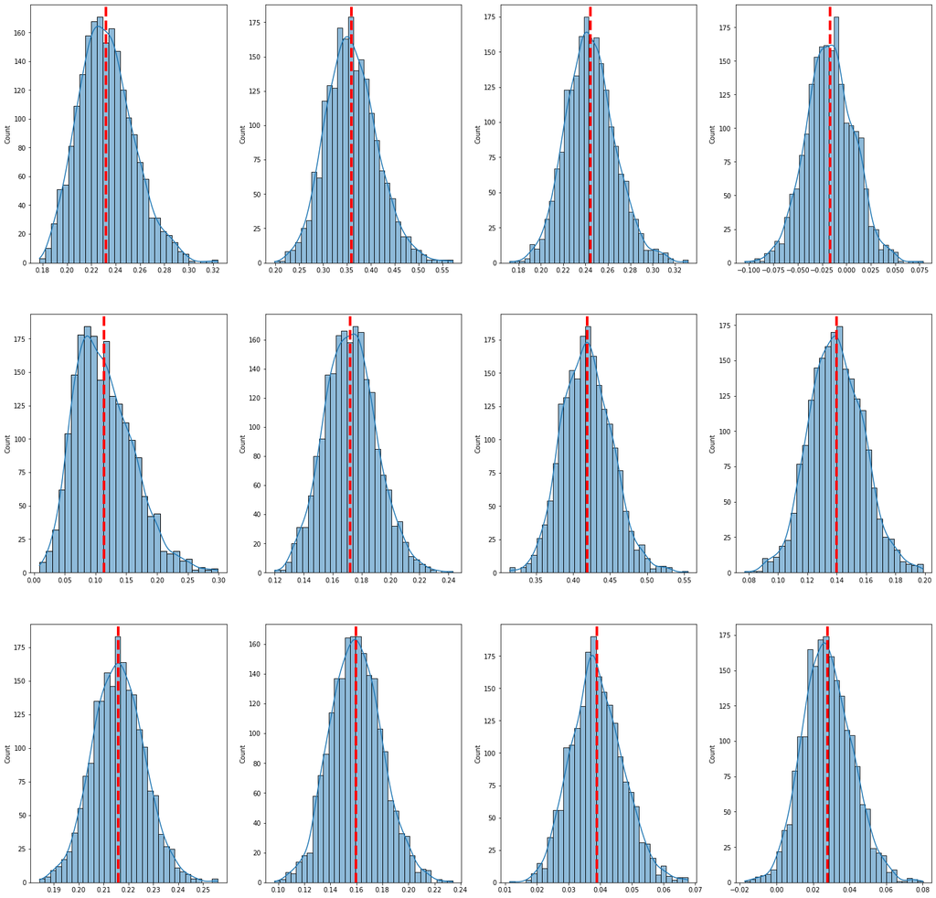

```python
plot_two_sample_boot(na_genre_sales, jp_genre_sales, 2000, ' Genre for bootstrap distribution', 'Genre sales (in millions)')
```

## Compute the cognostics of profitable gaming genres irrespective of region.

The second factor which I believe plays critical component in better understanding per-region genre growth, is market maturity of The North American, European and Japanese sales region, particularly when compared to those within "Other_Sales". The relatively slow growth of sales within these mature markets likely highlights both the increasingly competitive nature of the games industry. Furthermore, the sales trend of the shooter genre in North America likely underscores the oversaturation of Shooter-based titles in the region.

```python
# Compute the cognostics of the top 4 fastest selling game genres for each geographic region

# Following chapter 6, create intercept column in dataframe for linear reg. model
vgsales.loc[:,'intercept'] = [1.0] * vgsales.shape[0]


# Iterates over all sales regions, returns dict of genre sales slopes
# @param df      The dataframe to query
# @param column  The specified column to compute slopes
# @param regions The unique sales regions to iterate over
# @return        Dictionary of region/genre sale slopes key-value pairs
def get_region_slopes (df, column, regions):
    sales_slopes = {}

    for region in regions:
        slopes = []
        genres = []
        intercepts = []

        # CITATION: The following cognostic computation algorithm was created following
        # .. Professor Stephen F. Elston's 2020-2021 Lecture 6 material and is credited as the original author.
        for entry in df[column].unique():
            temp = df.loc[df[column] == entry]

            mean_sales = np.mean(temp[region])
            temp.loc[:,region] = np.subtract(temp[region], mean_sales)

            std_sales = np.std(temp[region])
            temp.loc[:,region] = np.divide(temp[region], std_sales)

            temp_OLS = sm.OLS(temp[region],temp[['intercept','Year']]).fit()

            slopes.append(temp_OLS.params.Year)
            intercepts.append(temp_OLS.params.intercept)
            genres.append(entry)

        slopes_df = pd.DataFrame({'slopes':slopes,'intercept_coef':intercepts,'genres':genres})
        slopes_df.sort_values(by='slopes', ascending=False, inplace=True)
        slopes_df.reset_index(inplace=True, drop=True)

        sales_slopes[region] = slopes_df

    return sales_slopes

region_slopes = get_region_slopes (vgsales, 'Genre', sales_groups)
```

[output not shown]

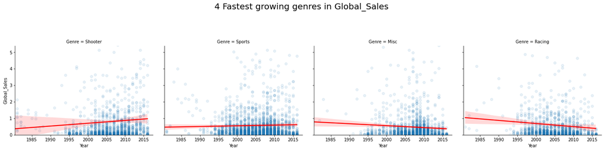

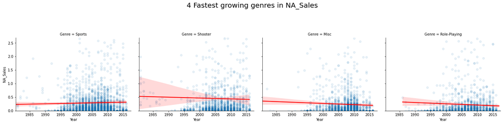

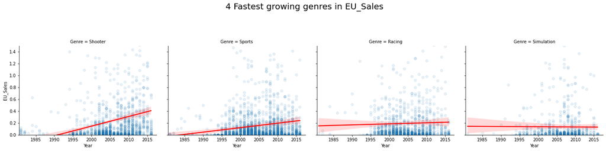

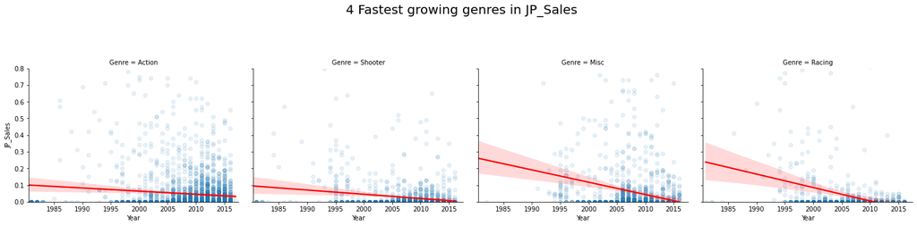

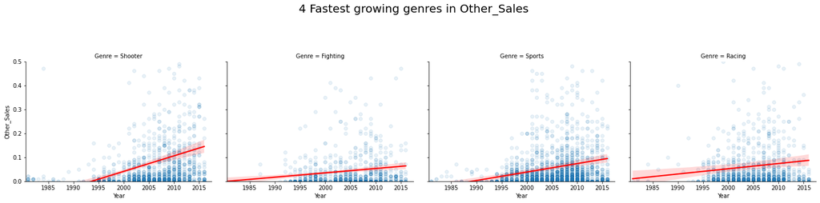

```python
# CITATION: The following cognostic plot algorithm was created following
# .. Professor Stephen F. Elston's 2020-2021 Lecture 6 material and is credited as the original author.

# Genreates a new plot for given region's sales genre slope
# @param df     The dataframe to query
# @param trend  The cognostic slope
# @param region The sales region containing the genre and slope
# @param title  The title of the plot
# @param xlims  The specified year range to display
# @param ylim   The specified sales range to display
def plot_trends(df, trend, region, title='', xlims=[1980.5, 2017.5], ylims=[None, None]):
    g = sns.FacetGrid(df, col='Genre', height=5, col_order=trend)
    g = g.map(sns.regplot,'Year', region, line_kws={'color':'red'}, scatter_kws={'alpha': 0.1})
    g.set(xlim=(xlims[0],xlims[1]))
    g.set(ylim=(ylims[0], ylims[1]))
    g.fig.subplots_adjust(top=0.7)
    g.fig.suptitle(title, fontsize=20)
    plt.show()


# Iterate over dict of slopes, plot n number of plots
# @param df     The dataframe to query
# @param slopes A dictionary of region slope key value pairs
# @param rng    The n number of slopes to compute
def display_sales_growth(df, slopes, rng=(0,9)):
    for region, slope in slopes.items():
        growth = slope.loc[rng[0]:rng[1], 'genres']
        title = (str(rng[1]+1) + ' Fastest growing genres in ' + region)
        ymax = np.round(df[region].mean()*10,1)
        plot_trends(vgsales, growth, region, title, ylims=[0,ymax])

display_sales_growth(vgsales, region_slopes, rng=(0,3))
```

## Projecting game sales with Bayesian Modelling

```python
# One Hot encode each region sales
global_sales_dummies = []
na_sales_dummies = []
eu_sales_dummies = []
jp_sales_dummies = []
other_sales_dummies = []

# Iterate over dataframe, encode all regional sales values
for index, row in vgsales.iterrows():

    # Encode sales as success if recieved atleast 1mill in sales
    global_sales_dummies.append(0 if row['Global_Sales'] < 1 else 1)
    na_sales_dummies.append(0 if row['NA_Sales'] < 1 else 1)
    eu_sales_dummies.append(0 if row['EU_Sales'] < 1 else 1)
    jp_sales_dummies.append(0 if row['JP_Sales'] < 1 else 1)
    other_sales_dummies.append(0 if row['Other_Sales'] < 1 else 1)

vgsales['Global_Sales_Encode'] = global_sales_dummies
vgsales['NA_Sales_Encode'] = na_sales_dummies
vgsales['EU_Sales_Encode'] = eu_sales_dummies
vgsales['JP_Sales_Encode'] = jp_sales_dummies
vgsales['Other_Sales_Encode'] = other_sales_dummies

vgsales.head()
```

|  | Rank | Name | Platform | Year | Genre | Publisher | NA_Sales | EU_Sales | JP_Sales | Other_Sales | Global_Sales | intercept | Global_Sales_Encode | NA_Sales_Encode | EU_Sales_Encode | JP_Sales_Encode | Other_Sales_Encode |
| --- | --- | --- | --- | --- | --- | --- | --- | --- | --- | --- | --- | --- | --- | --- | --- | --- | --- |
| 0 | 1 | Wii Sports | Wii | 2006.0 | Sports | Nintendo | 41.49 | 29.02 | 3.77 | 8.46 | 82.74 | 1.0 | 1 | 1 | 1 | 1 | 1 |
| 1 | 2 | Super Mario Bros. | NES | 1985.0 | Platform | Nintendo | 29.08 | 3.58 | 6.81 | 0.77 | 40.24 | 1.0 | 1 | 1 | 1 | 1 | 0 |
| 2 | 3 | Mario Kart Wii | Wii | 2008.0 | Racing | Nintendo | 15.85 | 12.88 | 3.79 | 3.31 | 35.82 | 1.0 | 1 | 1 | 1 | 1 | 1 |
| 3 | 4 | Wii Sports Resort | Wii | 2009.0 | Sports | Nintendo | 15.75 | 11.01 | 3.28 | 2.96 | 33.00 | 1.0 | 1 | 1 | 1 | 1 | 1 |
| 4 | 5 | Pokemon Red/Pokemon Blue | GB | 1996.0 | Role-Playing | Nintendo | 11.27 | 8.89 | 10.22 | 1.00 | 31.37 | 1.0 | 1 | 1 | 1 | 1 | 1 |

```python
action_sales = vgsales['NA_Sales_Encode'].loc[(vgsales['Genre'] == 'Action') & (vgsales['Year'].isin([1990.0,1995.0]))]
action_sales.sum()
```

```
3
```

Following the successful enccoding of each genre's sales within their respective geographic region, we are now presented with the critical task of identifying a prior distribution for our Bayesian model. However, notice the relatively few number of queried results, as well as the small number of classifications of successful game sales. Despite the wide diversity of title entries in the dataset, the data still falls victim to the historical trends of game sales in their given year. Specifically, the number of titles for a given genre released earlier in the dataset will be fewer than those released presently, as previously demonstrated by the growth of genres in each given region.

With the limited sample size of game sales, the prior distribution will be computed using the known likelihood of platform sales between 1990-1995 multiplied by a beta conjugate distribution. A beta conjugate was selected given the binomial nature of the commerical success/failure encoding previous computed.

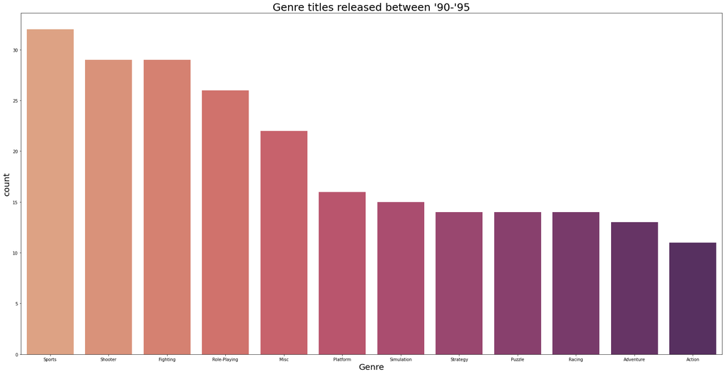

```python
genre_counts = vgsales['Genre'].loc[(vgsales['Year'].isin([1990.0,1995.0]))]

fig, ax = plt.subplots(figsize=(30,15))
ax = sns.countplot(x=genre_counts, order=genre_counts.value_counts().index,
                   palette=sns.color_palette('flare', n_colors=12))
ax.set_title('Genre titles released between \'90-\'95', fontsize=25)
ax.xaxis.get_label().set_fontsize(20)
ax.yaxis.get_label().set_fontsize(20)
plt.show()
```

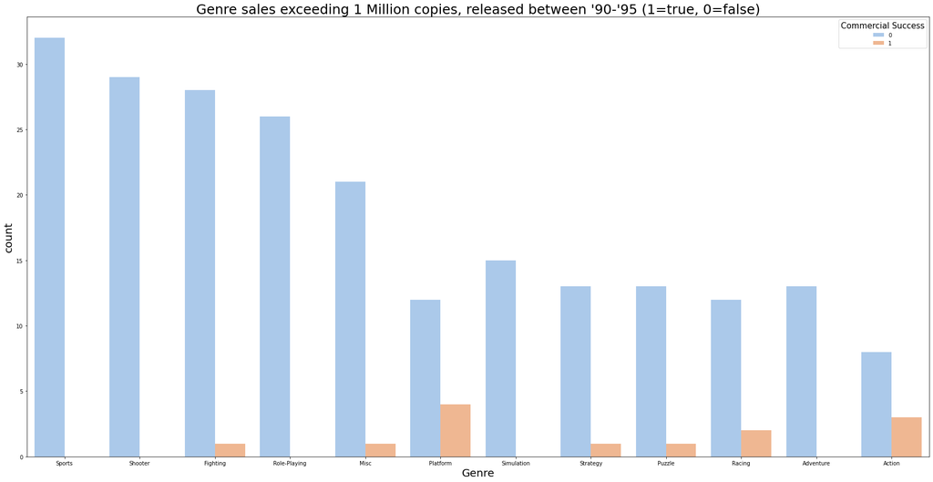

```python
genre_sales = vgsales[['NA_Sales_Encode', 'Genre']].loc[(vgsales['Year'].isin([1990.0,1995.0]))]

fig, ax = plt.subplots(figsize=(30,15))
_=sns.countplot(x='Genre', hue='NA_Sales_Encode', order=genre_sales['Genre'].value_counts().index,
                 palette='pastel', data=genre_sales, ax=ax)
ax.set_title('Genre sales exceeding 1 Million copies, released between \'90-\'95 (1=true, 0=false)', fontsize=25)
ax.legend(title="Commercial Success", title_fontsize='15')
ax.xaxis.get_label().set_fontsize(20)
ax.yaxis.get_label().set_fontsize(20)
plt.show()
```

```python
platform_sales = vgsales['NA_Sales_Encode'].loc[(vgsales['Genre'] == 'Platform') & (vgsales['Year'].isin([1990.0,1995.0]))]
platform_sales.sum()
```

```
4
```

```python
# CITATION: The following distribution plot functions were created following
# .. Professor Stephen F. Elston's 2020-2021 Lecture 7 material and is credited as the original author.

# Plots given distribution over sample space
# @param title        Title of the plot
# @param xlable       X axis lable for the plot
# @param distribution Distribution to be plotted
# @param p            Sample space
def plot_distribution (title, xlabel, distribution, p):
    fig, ax = plt.subplots(figsize=(10, 4))
    ax.plot(p, distribution)
    ax.set_title(title)
    ax.set_xlabel(xlabel)
    ax.set_ylabel('Distribution')
    plt.show()

# Resamples and Plots given density of samples in distribution
# @param title        Title of the plot
# @param xlable       X axis lable for the plot
# @param size         Number of desired resamples
# @param distribution Distribution to be plotted
# @param p            Sample space
def plot_density(title, xlabel, size, p, distribution):
    resamples = np.random.choice(p, size=size, p=distribution)

    plt.hist(resamples, bins=20, density=True)
    plt.title(title)
    plt.ylabel('Density')
    plt.xlabel(xlabel)
    plt.show()
```

```python
# Computes the likelihhood of a given distribution
# @param p Sample count
# @param k Success count
# @param n Param shape
# @return  Distribution likelihood
def compute_likelihood(p, k, n):
    # Given the two possible categorizations for succesfful sales (either reaching 1mill or not),
    # .. leverage binomal likelihood
    return scipy.stats.binom.pmf(k, n, p)

# Computes a Beta distribution of a given distribution
# @param p Sample count
# @param k Pseudo success count
# @param k Pseudo failure count
# @param n Param shape
# @return  Probability distribution
def compute_beta_prior(p, a, b, n):
    pp = scipy.stats.beta.pdf(p, a, b)/n
    return pp

# Computes a posterior using prior and likelihood
# @param prior The prior distribution
# @param like  The likelihood of the prior distribution
# @return      Normalized Posterior distribution
def compute_posterior(prior, like):

    # CITATION: The following posterior calcuation algorithm was created following
    # .. Professor Stephen F. Elston's 2020-2021 Lecture 7 material
    posterior = np.multiply(prior, like)
    return np.divide(posterior, posterior.sum())
```

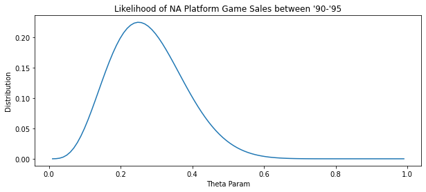

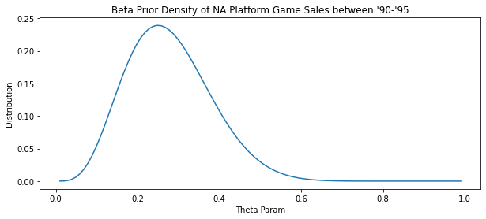

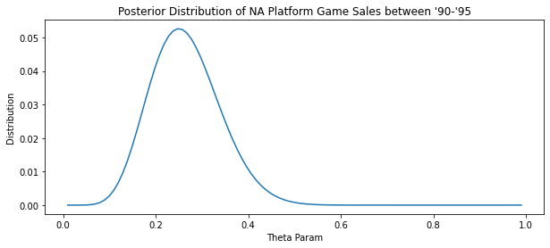

```python
k = sum(platform_sales)
n = len(platform_sales)
p = np.linspace(.01, .99, num=100)

# Compute and Plot likelihood distribution
l = compute_likelihood(p, k, n)

title = 'Likelihood of NA Platform Game Sales between \'90-\'95'
xlabel = 'Theta Param'
plot_distribution(title, xlabel, l, p)

# Compute and Plot beta prior distribution
beta_prior = compute_beta_prior(p, (k+1), ((n-k)+1), n)

title = 'Beta Prior Density of NA Platform Game Sales between \'90-\'95'
xlabel = 'Theta Param'
plot_distribution(title, xlabel, beta_prior, p)

# Compute and Plot posterior distribution
post = compute_posterior(beta_prior, l)

title = 'Posterior Distribution of NA Platform Game Sales between \'90-\'95'
xlabel = 'Theta Param'
plot_distribution(title, xlabel, post, p)
```

```python
# Obtain all Encoded Eu platform game sales for the following 5 year window between 1995 - 2000
eu_platform_sales = vgsales['EU_Sales_Encode'].loc[(vgsales['Genre'] == 'Platform') & (vgsales['Year'].isin([1995.0,2000.0]))]
```

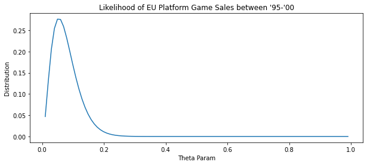

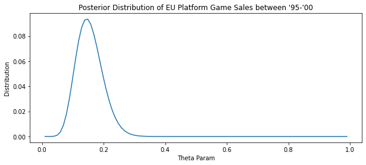

```python
# Update model with data from EU sister region
k = sum(eu_platform_sales)
n = len(eu_platform_sales)

# Compute and Plot likelihood distribution
l = compute_likelihood(p, k, n)

title = 'Likelihood of EU Platform Game Sales between \'95-\'00'
xlabel = 'Theta Param'
plot_distribution(title, xlabel, l, p)

# Compute and Plot posterior distribution
post_updated = compute_posterior(post, l)

title = 'Posterior Distribution of EU Platform Game Sales between \'95-\'00'
xlabel = 'Theta Param'
plot_distribution(title, xlabel, post_updated, p)
```

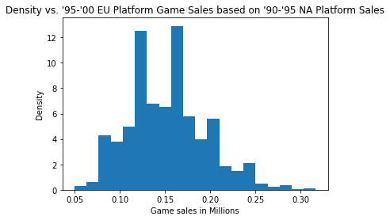

```python
# Simulate posterior predictions
title = 'Density vs. \'95-\'00 EU Platform Game Sales based on \'90-\'95 NA Platform Sales'
xlabel = 'Game sales in Millions'

plot_density(title, xlabel, 2000, p, post_updated)
```

The insights from these results are particularly interesting. Our predicition of platform game sales between 1995 and 2000 indicate a high probability of game sales reaching roughly 170,000 copies sold. Assuming each title is sold to consumers for roughly \$60 USD, plublishers can expect around \\$10.2 Million in revenue from game purchases alone (not accounting for inflation).

To better understand how this sales projection relates to the larger trend of historical video game sales, let us compare the profitability of games recently released. Yet given the previous evidence regarding too few classifications of commercially successful games, a revaluation of genre titles released and their sales performance should be recomuted.

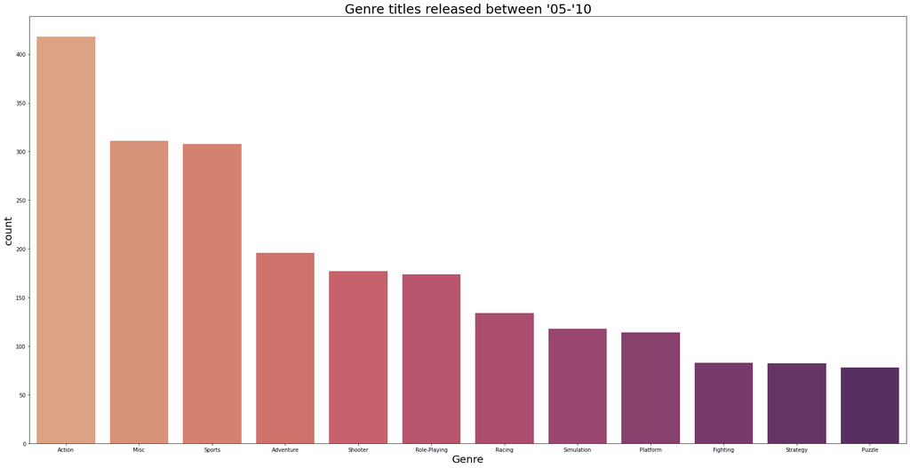

```python
genre_counts = vgsales['Genre'].loc[(vgsales['Year'].isin([2005.0,2010.0]))]

fig, ax = plt.subplots(figsize=(30,15))
ax = sns.countplot(x=genre_counts, order=genre_counts.value_counts().index,
                   palette=sns.color_palette('flare', n_colors=12))
ax.set_title('Genre titles released between \'05-\'10', fontsize=25)
ax.xaxis.get_label().set_fontsize(20)
ax.yaxis.get_label().set_fontsize(20)
plt.show()
```

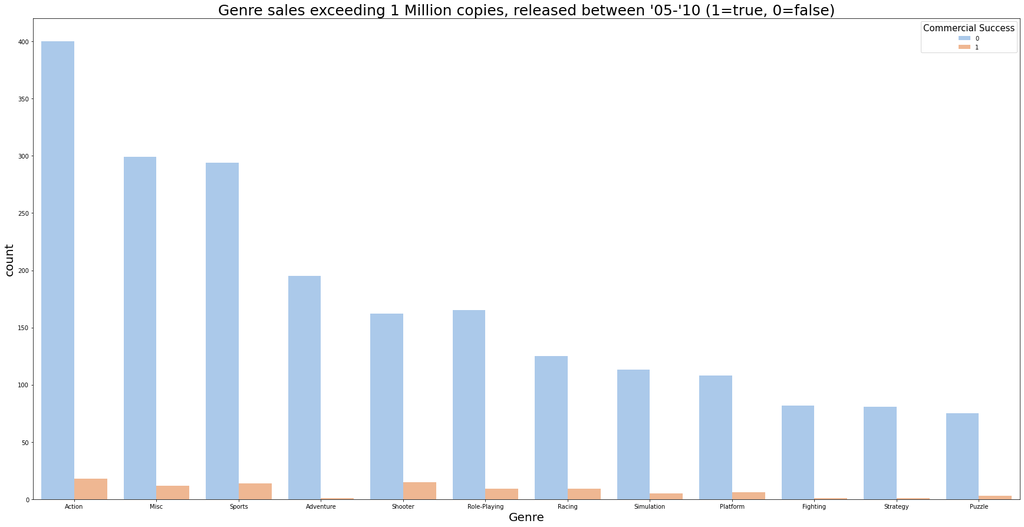

```python
genre_sales = vgsales[['NA_Sales_Encode', 'Genre']].loc[(vgsales['Year'].isin([2005.0,2010.0]))]

fig, ax = plt.subplots(figsize=(30,15))
_=sns.countplot(x='Genre', hue='NA_Sales_Encode', order=genre_sales['Genre'].value_counts().index,
                 palette='pastel', data=genre_sales, ax=ax)
ax.set_title('Genre sales exceeding 1 Million copies, released between \'05-\'10 (1=true, 0=false)', fontsize=25)
ax.legend(title="Commercial Success", title_fontsize='15')
ax.xaxis.get_label().set_fontsize(20)
ax.yaxis.get_label().set_fontsize(20)
plt.show()
```

Once again the results of this visualization confirm a shift in consumer purchasing trends. Within a 20 year window, North American game enthusiasts appear to strongly prefer action related titles. The insight runs contrary to the past consumer preferences in the 90's, which featured gamers prefering sports related titles. However, despite the massive growth in popularity (of all genres sold across the board), the number of action related titles that classify as a commercial success are far and few. Understanding this new information underscores the both the highly competitive nature of game developement/publishing, as well as the market saturation of titles competing with one and other. Therefore, we may infer that the likelihood of any given genre in the North American market achiving a minimum of 1 million units sold is unlikely. Instead, let us simulate the projected unit sales of action related titles in the European market place.

```python
action_sales = vgsales['NA_Sales_Encode'].loc[(vgsales['Genre'] == 'Action') & (vgsales['Year'].isin([2005.0,2010.0]))]
action_sales.sum()
```

```
18
```

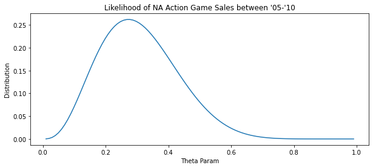

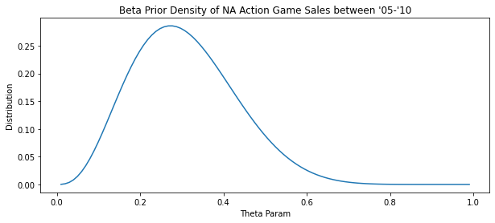

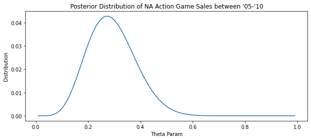

```python
k = sum(action_sales)
n = len(action_sales)
p = np.linspace(.01, .99, num=100)

# Compute and Plot likelihood distribution
l = compute_likelihood(p, k, n)

title = 'Likelihood of NA Action Game Sales between \'05-\'10'
xlabel = 'Theta Param'
plot_distribution(title, xlabel, l, p)

# Compute and Plot beta prior distribution
beta_prior = compute_beta_prior(p, (k+1), ((n-k)+1), n)

title = 'Beta Prior Density of NA Action Game Sales between \'05-\'10'
xlabel = 'Theta Param'
plot_distribution(title, xlabel, beta_prior, p)

# Compute and Plot posterior distribution
post = compute_posterior(beta_prior, l)

title = 'Posterior Distribution of NA Action Game Sales between \'05-\'10'
xlabel = 'Theta Param'
plot_distribution(title, xlabel, post, p)
```

```python
# Obtain all Encoded Eu action game sales for the following 5 year window between 2010 - 2015
eu_action_sales = vgsales['EU_Sales_Encode'].loc[(vgsales['Genre'] == 'Action') & (vgsales['Year'].isin([2010.0,2015.0]))]
```

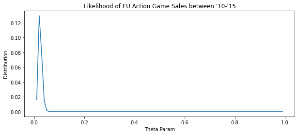

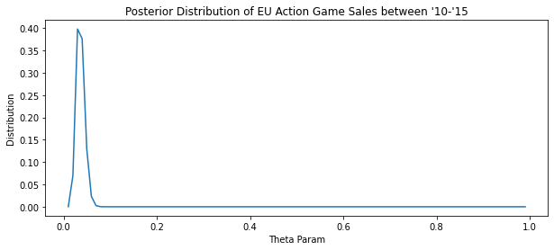

```python
# Update model with data from EU sister region
k = sum(eu_action_sales)
n = len(eu_action_sales)

# Compute and Plot likelihood distribution
l = compute_likelihood(p, k, n)

title = 'Likelihood of EU Action Game Sales between \'10-\'15'
xlabel = 'Theta Param'
plot_distribution(title, xlabel, l, p)

# Compute and Plot posterior distribution
post_updated = compute_posterior(post, l)

title = 'Posterior Distribution of EU Action Game Sales between \'10-\'15'
xlabel = 'Theta Param'
plot_distribution(title, xlabel, post_updated, p)
```

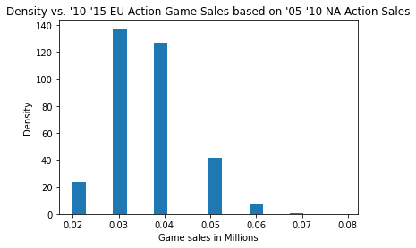

```python
# Simulate posterior predictions
title = 'Density vs. \'10-\'15 EU Action Game Sales based on \'05-\'10 NA Action Sales'
xlabel = 'Game sales in Millions'

plot_density(title, xlabel, 2000, p, post_updated)
```

Unlike the results from European projected platform genre sales within a five year windows during the 90's, the modern sales results from European action titles indicates a more conservative sales projection. The predicition of action game sales between 2010 and 2015 indicate a high probability of game sales reaching roughly 30,000 - 40,000 copies sold. Assuming each title is sold to consumers for roughly \$60 USD, plublishers can expect around \\$1.8 Million in revenue from game purchases alone (not accounting for inflation). While the predictions generated are biased towards their respective genres, and feature significant temporal differences, there are insights to be made regarding popularity. First, despite the lower projected action sales numbers compared to platformers in the 90's, the magnitude of titles sold (regardless of genre) has increased significantly. This evidence should underscore the rapid growth in popularity of video games in western markets.

## Citations

[1] Smith, G. (2016, October 26). Video Game Sales. Kaggle. https://www.kaggle.com/gregorut/videogamesales.  
[2] Hunt, N., & Moar, J. (2020). (rep.). Video Games : Industry Trends, Monetisation Strategies & Market Size 2020-2025. Juniper Research. https://www.juniperresearch.com/researchstore/content-digital-media/video-games-market-report  
[3] Takahashi, D. (2020, June 16). Epic Games seeking to sell stake for \$750 million at \\$17 billion valuation. VentureBeat. https://venturebeat.com/2020/06/15/epic-games-shareholders-seeking-to-sell-stake-for-750-million-at-17-billion-valuation/.  
[4] Video Game Charts, Game Sales, Top Sellers, Game Data. VGChartz. https://www.vgchartz.com/.  
[5] The Nielsen Company. (2018). (rep.). U.S. Games 360 Report: 2018. https://www.nielsen.com/us/en/insights/report/2018/us-games-360-report-2018/  
[6] (2016). www.e-stat.go.jp/SG1/estat/XlsdlE.do?sinfid=000031594636.  
[7] The Global Games Market Will Generate $152.1 Billion in 2019 as the U.S. Overtakes China as the Biggest Market. Newzoo. (2019, December 18). https://newzoo.com/insights/articles/the-global-games-market-will-generate-152-1-billion-in-2019-as-the-u-s-overtakes-china-as-the-biggest-market/  
[8] Stephen Elston, CSCI-E-83, (2021), GitHub repository, https://github.com/StephenElston/CSCI-E-83